# PartOne

```python
import pandas as pd
data_path = 'midterm_partone.csv'
data = pd.read_csv(data_path)
data.head()
```

|  | Constant | Stock Change | Inventory Turnover | Operating Profit | Interaction Effect | Current Ratio | Quick Ratio | Debt Asset Ratio |
| --- | --- | --- | --- | --- | --- | --- | --- | --- |
| 0 | 1 | 0.870332 | 1.795946 | 0.115846 | 0.208053 | 1.672527 | 0.255171 | 0.473317 |
| 1 | 1 | -0.047347 | 1.395501 | 0.436967 | 0.609788 | 1.637261 | 0.221763 | 0.489967 |
| 2 | 1 | 0.001176 | 1.664563 | 0.541016 | 0.900555 | 1.640619 | 0.189141 | 0.374269 |
| 3 | 1 | -0.901200 | 1.605738 | 0.539399 | 0.866133 | 1.436221 | 0.131944 | 0.224399 |
| 4 | 1 | -0.176353 | 1.591451 | 0.539938 | 0.859285 | 1.433140 | 0.183095 | 0.213446 |

```python
print(data.describe())
```

```
       Constant  Stock Change  Inventory Turnover  Operating Profit  \
count    1696.0   1696.000000         1696.000000       1696.000000
mean        1.0     -0.012977           24.633183          0.255719
std         0.0      0.490888           37.044608          0.590330
min         1.0     -2.366261            0.996475         -5.989709
25%         1.0     -0.258291            3.733259          0.151177
50%         1.0     -0.005839            6.372805          0.244090
75%         1.0      0.234015           29.433657          0.338010
max         1.0      4.138063          240.046041          7.450718

       Interaction Effect  Current Ratio  Quick Ratio  Debt Asset Ratio
count         1696.000000    1696.000000  1696.000000       1696.000000
mean             6.584336       1.972308     1.069610          0.150254
std             42.544580       1.509598     1.161417          0.275665
min           -411.751139       0.202040     0.035457          0.000000
25%              0.646555       1.079045     0.366561          0.000000
50%              1.596459       1.585408     0.694119          0.037937
75%              5.298054       2.364317     1.258383          0.236709
max            884.467955      13.026268    10.501619          3.675735
```

```python
print(data.isnull().sum())
```

```
Constant              0
Stock Change          0
Inventory Turnover    0
Operating Profit      0
Interaction Effect    0
Current Ratio         0
Quick Ratio           0
Debt Asset Ratio      0
dtype: int64
```

```python
Y = data['Stock Change']
X = data[['Constant', 'Inventory Turnover', 'Operating Profit', 'Interaction Effect', 'Current Ratio', 'Quick Ratio', 'Debt Asset Ratio']]
```

```python
from statsmodels.sandbox.regression.gmm import IVGMM
Z = X
model = IVGMM(endog=Y, exog=X, instrument=Z)
results = model.fit()

# Display the summary
print(results.summary())
```

```
Optimization terminated successfully.
         Current function value: 0.000000
         Iterations: 17
         Function evaluations: 20
         Gradient evaluations: 20
Optimization terminated successfully.
         Current function value: 0.000000
         Iterations: 1
         Function evaluations: 3
         Gradient evaluations: 3
Optimization terminated successfully.
         Current function value: 0.000000
         Iterations: 0
         Function evaluations: 1
         Gradient evaluations: 1
Optimization terminated successfully.
         Current function value: 0.000000
         Iterations: 0
         Function evaluations: 1
         Gradient evaluations: 1
                                IVGMM Results
==============================================================================
Dep. Variable:           Stock Change   Hansen J:                    4.101e-10
Model:                          IVGMM   Prob (Hansen J):                   nan
Method:                           GMM
Date:                Thu, 07 Mar 2024
Time:                        11:08:14
No. Observations:                1696
======================================================================================
                         coef    std err          z      P>|z|      [0.025      0.975]
--------------------------------------------------------------------------------------
Constant               0.0401      0.031      1.308      0.191      -0.020       0.100
Inventory Turnover  1.488e-05      0.000      0.035      0.972      -0.001       0.001
Operating Profit      -0.1211      0.031     -3.944      0.000      -0.181      -0.061
Interaction Effect     0.0014      0.000      3.715      0.000       0.001       0.002
Current Ratio         -0.0282      0.019     -1.509      0.131      -0.065       0.008
Quick Ratio            0.0223      0.022      0.994      0.320      -0.022       0.066
Debt Asset Ratio       0.0009      0.038      0.024      0.981      -0.073       0.075
======================================================================================
```

The statistically significant variables are Operating Profit and Interaction Effect, both showing a strong relationship with Stock Change. The Operating Profit's negative coefficient suggests that an increase in operating profit is associated with a decrease in stock change, under the model's specifications. The Interaction Effect's positive coefficient indicates its positive influence on stock change. Given these results, it seems there are indeed some variables with a significant impact on the dependent variable (Stock Change), while others show little to no effect. The expert's concern about a potential bias in the moment conditions could be further investigated by examining the selection and validity of instruments or exploring alternative modeling approaches to address any potential endogeneity issues more directly

Customized GMM Model:

```python
def moment_conditions(params, Y, X, Z):
    beta = params[:-1]
    delta = params[-1]
    errors = Y - (X @ beta + delta)
    moments = Z.T @ errors
    return np.array(moments)
```

```python
from scipy.optimize import minimize
import numpy as np
def gmm_criterion(params, Y, X, Z):
    moments = moment_conditions(params, Y, X, Z)
    return np.sum(moments**2)

# Initial guesses for parameters
initial_params = np.zeros(X.shape[1] + 1)  # Including beta and delta

# Optimization
result = minimize(fun=gmm_criterion, x0=initial_params, args=(Y, X, Z), method='L-BFGS-B')
print("Estimated parameters (beta and delta):", result.x)
```

```
Estimated parameters (beta and delta): [-0.01388721  0.00064066 -0.02004643  0.00040452 -0.00849084  0.00968477
 -0.00102501 -0.01388721]
```

Interpreting δ: If the last parameter correctly represented δ without duplication errors and its value would indicate the magnitude and direction of the specific bias or effect δ was intended to capture. A value significantly different from zero would suggest that δ has a noticeable impact on model and supporting the idea that effect or bias δ represents is present in the data. If δ is significantly different from zero (considering the context of model and scale of dependent variable), it suggests that the expert's claim of a bias in the moment conditions might be justified. The significance here can be further assessed by looking into the standard errors and confidence intervals, which would require additional steps. If δ is close to zero or not significantly different from zero. it would suggest that moment conditions might not be biased in the way the expert claimed, or the bias is not statistically significant in your model.

```python
def moment_conditions(params, Y, X, Z):
    beta = params[:-1]
    delta = params[-1]
    errors = Y - np.dot(X, beta) - delta
    moments = np.dot(errors, Z)
    return moments
```

```python
def jacobian_estimation(params, Y, X, Z, epsilon=1e-5):
    f = lambda p: np.sum(moment_conditions(p, Y, X, Z))
    num_params = len(params)
    jacobian = np.zeros(num_params)
    for i in range(num_params):
        eps_vector = np.zeros(num_params)
        eps_vector[i] = epsilon
        # Calculate gradient for each parameter
        jacobian[i] = (f(params + eps_vector) - f(params - eps_vector)) / (2*epsilon)
    return jacobian
```

```python
def gmm_criterion(params, Y, X, Z):
    moments = moment_conditions(params, Y, X, Z)
    return np.sum(moments**2)
```

```python
from scipy.optimize import minimize
import numpy as np

# Ensure Y, X, Z are numpy arrays
Y_np = Y.to_numpy()
X_np = X.to_numpy()
Z_np = Z.to_numpy()

initial_params = np.zeros(X_np.shape[1] + 1)

result = minimize(fun=gmm_criterion, x0=initial_params, args=(Y_np, X_np, Z_np), method='L-BFGS-B')

print("Optimization result:", result)
print("Estimated parameters (beta and delta):", result.x)
```

```
Optimization result:   message: CONVERGENCE: REL_REDUCTION_OF_F_<=_FACTR*EPSMCH
  success: True
   status: 0
      fun: 27.24503836602667
        x: [ 9.246e-03  2.155e-04 -1.166e-01  1.368e-03 -1.225e-02
             4.525e-03  1.184e-02  9.246e-03]
      nit: 52
      jac: [ 9.751e+02  1.021e+05 -4.131e+01  3.157e+04  5.677e+03
             7.813e+02 -1.047e+02  9.751e+02]
     nfev: 945
     njev: 105
 hess_inv: <8x8 LbfgsInvHessProduct with dtype=float64>
Estimated parameters (beta and delta): [ 0.00924552  0.00021549 -0.1165653   0.00136759 -0.01225424  0.00452497
  0.01183712  0.00924552]
```

```python
params_estimates = result.x
standard_errors = np.sqrt(np.diag(np.linalg.inv(np.dot(Z_np.T, Z_np))))
print("Standard errors (approximated):", standard_errors)
```

```
Standard errors (approximated): [0.06158284 0.00081856 0.05795398 0.00082521 0.04070379 0.04992742
 0.09100695]
```

```python
import scipy.stats

confidence_level = 0.95
z_score = scipy.stats.norm.ppf(1 - (1 - confidence_level) / 2)

confidence_intervals = [(estimate - z_score * se, estimate + z_score * se)
                        for estimate, se in zip(params_estimates, standard_errors)]
print("Confidence intervals:", confidence_intervals)
```

[output not shown]

```python
delta_estimate = params_estimates[-1]
delta_se = standard_errors[-1]

t_statistic = delta_estimate / delta_se
p_value = 2 * (1 - scipy.stats.norm.cdf(abs(t_statistic)))

print(f"Delta estimate: {delta_estimate}, Standard Error: {delta_se}, t-statistic: {t_statistic}, p-value: {p_value}")
```

```
Delta estimate: 0.00924552331470718, Standard Error: 0.0910069511471762, t-statistic: 0.1015913971203732, p-value: 0.9190810082218741
```

Given the p-value of 0.919 which is much higher than the common threshold of 0.05 we do not have evidence to reject the null hypothesis that δ=0. This suggests that the bias δ intended to capture in the moment conditions of your GMM model is not statistically significant from zero at conventional significance levels. In simpler terms, there isn't strong statistical evidence to support the claim that there is a notable bias (δ being non-zero) in the instrumental-variable moment conditions based in model and the data analyzed.

# PartTwo

```python
import pandas as pd
import numpy as np
from sklearn.model_selection import train_test_split
from sklearn.linear_model import LogisticRegression
from sklearn.metrics import confusion_matrix, recall_score, precision_score, f1_score, roc_curve, auc
from sklearn.preprocessing import LabelEncoder
import matplotlib.pyplot as plt
import warnings
warnings.filterwarnings('ignore')
```

```python
data = pd.read_csv('midterm_parttwo.csv')
data.head()
```

|  | Years of Education after High School | Requested Credit Amount | Number of Dependents | Monthly Income | Monthly Expense | Marital Status | Credit Rating |
| --- | --- | --- | --- | --- | --- | --- | --- |
| 0 | 1 | Low | No dependent | Very low | Very low | Married | Positive |
| 1 | 2 | Low | No dependent | Very low | Very low | Single | Positive |
| 2 | 1 | Low | No dependent | Very low | Very low | Single | Positive |
| 3 | 3 | Low | No dependent | Very low | Very low | Married | Positive |
| 4 | 3 | Low | No dependent | Very low | Very low | Single | Negative |

```python
data.columns = data.columns.str.strip().str.lower()
```

```python
print(data.columns)
```

```
Index(['years of education after high school', 'requested credit amount',
       'number of dependents', 'monthly income', 'monthly expense',
       'marital status', 'credit rating'],
      dtype='object')
```

```python
data.head()
```

|  | years of education after high school | requested credit amount | number of dependents | monthly income | monthly expense | marital status | credit rating |
| --- | --- | --- | --- | --- | --- | --- | --- |
| 0 | 1 | Low | No dependent | Very low | Very low | Married | Positive |
| 1 | 2 | Low | No dependent | Very low | Very low | Single | Positive |
| 2 | 1 | Low | No dependent | Very low | Very low | Single | Positive |
| 3 | 3 | Low | No dependent | Very low | Very low | Married | Positive |
| 4 | 3 | Low | No dependent | Very low | Very low | Single | Negative |

```python
dependent_var = 'credit rating'
```

```python
X = data.drop([dependent_var], axis=1)
categorical_vars = X.select_dtypes(include=['object']).columns
X = pd.get_dummies(X, columns=categorical_vars)
```

```python
# Encode the target variable
y = LabelEncoder().fit_transform(data[dependent_var])
```

```python
# Split the dataset into training and test sets
X_train, X_test, y_train, y_test = train_test_split(X, y, test_size=0.5, random_state=42)

# Fit a logistic regression model
model = LogisticRegression(max_iter=1000, solver='liblinear')
model.fit(X_train, y_train)
```

```
LogisticRegression(max_iter=1000, solver='liblinear')
```

```python
# Initial Model Evaluation
y_pred = model.predict(X_test)
print(f'Initial Confusion Matrix:\n{confusion_matrix(y_test, y_pred)}')
print(f'Recall: {recall_score(y_test, y_pred, average="weighted")}')
print(f'Precision: {precision_score(y_test, y_pred, average="weighted")}')
print(f'F1 Score: {f1_score(y_test, y_pred, average="weighted")}')
```

```
Initial Confusion Matrix:
[[   0  577]
 [   0 3464]]
Recall: 0.8572135609997525
Precision: 0.7348150891618765
F1 Score: 0.7913092006137622
```

```python
# Adjusting the Decision Threshold for 15% Approval
y_pred_probs = model.predict_proba(X_test)[:, 1]
threshold = np.percentile(y_pred_probs, 85)
y_pred_adjusted = (y_pred_probs >= threshold).astype(int)
```

```python
# Evaluation with Adjusted Threshold
print(f'Adjusted Confusion Matrix:\n{confusion_matrix(y_test, y_pred_adjusted)}')
print(f'Adjusted Recall: {recall_score(y_test, y_pred_adjusted, average="weighted")}')
print(f'Adjusted Precision: {precision_score(y_test, y_pred_adjusted, average="weighted")}')
print(f'Adjusted F1 Score: {f1_score(y_test, y_pred_adjusted, average="weighted")}')
```

```
Adjusted Confusion Matrix:
[[ 495   82]
 [2939  525]]
Adjusted Recall: 0.2524127691165553
Adjusted Precision: 0.7619942621668829
Adjusted F1 Score: 0.25633686495439034
```

```python
# Visualization
fpr, tpr, _ = roc_curve(y_test, y_pred_probs)
roc_auc = auc(fpr, tpr)
```

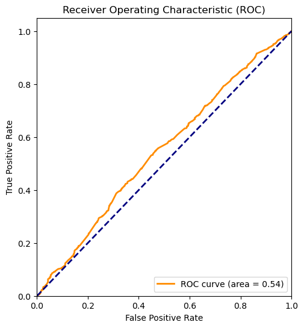

```python
plt.figure(figsize=(12, 6))
plt.subplot(1, 2, 1)
plt.plot(fpr, tpr, color='darkorange', lw=2, label=f'ROC curve (area = {roc_auc:.2f})')
plt.plot([0, 1], [0, 1], color='navy', lw=2, linestyle='--')
plt.xlim([0.0, 1.0])
plt.ylim([0.0, 1.05])
plt.xlabel('False Positive Rate')
plt.ylabel('True Positive Rate')
plt.title('Receiver Operating Characteristic (ROC)')
plt.legend(loc="lower right")
```

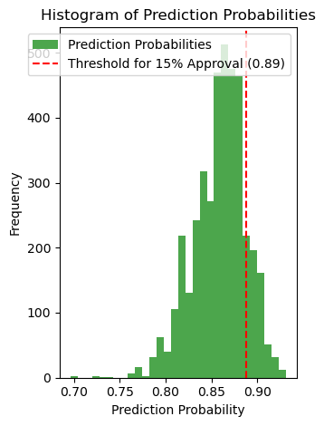

```python
plt.subplot(1, 2, 2)
plt.hist(y_pred_probs, bins=30, color='green', alpha=0.7, label='Prediction Probabilities')
plt.axvline(x=threshold, color='red', linestyle='--', label=f'Threshold for 15% Approval ({threshold:.2f})')
plt.xlabel('Prediction Probability')
plt.ylabel('Frequency')
plt.title('Histogram of Prediction Probabilities')
plt.legend()

plt.tight_layout()
plt.show()
```